# CSUF-Math536 Statistical Consultancy

Suggested Retail Car Price Report

Analyst: Seth Arreola

3/11/2022

### Indroduction

The following report was created at the CSUF-MATH536 Statistical Consultancy, at the request of Malcolm Reynolds. The purpose of this report is to assist in the analysis of auto-industry data. Specifically, the central goal is the statistical modeling of prices of new cars via several predictor variables (which are specs of the car). Questions that are of interest; what is the relationship between the predictors and the response (we explore this through EDA), and are any predictors unimportant in the prediction of new cars. Lastly, a prediction of the average price on a new vehicle with specific attributes is made at the request of Malcolm Reynolds is made.

### The Data

The data set contains several predictors, which are different specs of the cars and one primary-key variable which contains the vehicle make, model, and number of doors. We can use this to visualize the entierity of the data.

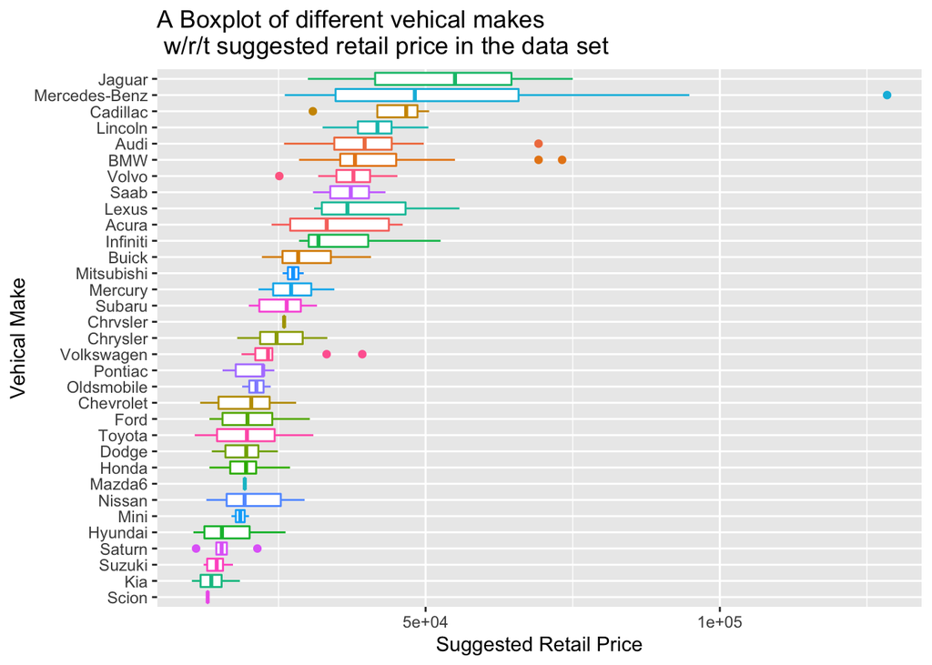

As we can see, the data received contains vehicles from multiple dealers, where vehicles from Jaguar and Mercedes-Benz have the highest median price. The following list shows the Vehical Makes that are most common in the data

| Make | n |
| --- | --- |
| Mercedes-Benz | 15 |
| Toyota | 15 |
| Audi | 13 |
| BMW | 13 |
| Chevrolet | 13 |
| Honda | 11 |
| Chrysler | 10 |
| Ford | 10 |
| Hyundai | 10 |

Lastly, before analyzing the response and the remaining predictor variables, the primary-key variable is transformed to a categorical variable “Doors”, which states the number of doors the vehicle has. This will be added to the list of predictors to gain as much information from the data as possible. Dimension reduction for modeling purposes will be addressed later.

##### The response variable (Suggested-Retail-Price):

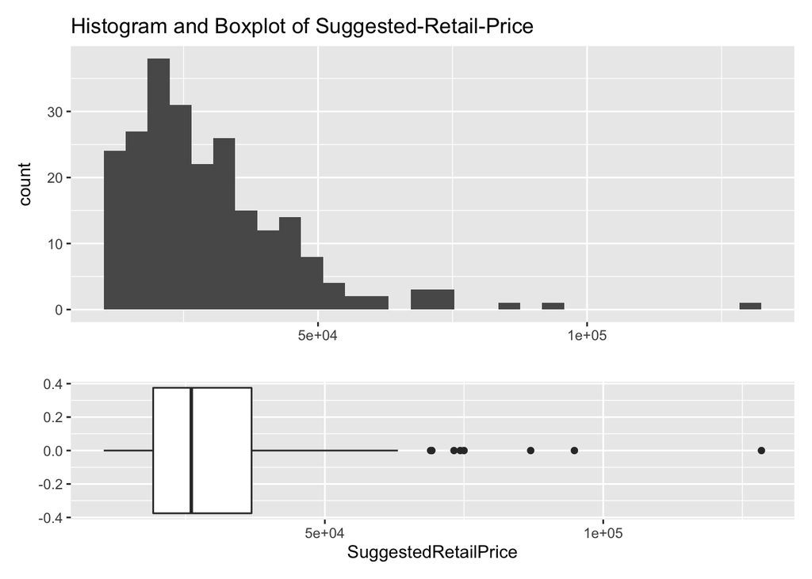

We can used these plots to get a general idea of the response variable. As shown in the plots most of the data is between 19,161 (1st Quantile), and 36,831 (3rd Quantile). Note the minimum value reported is 10,280 and we do see one very large value of 128,420. Specifications of the observation with the large value is shown below:

| Vehicle Name | Hybrid | SuggestedRetailPrice | EngineSize | Cylinders | Horsepower | HighwayMPG | Weight | WheelBase |
| --- | --- | --- | --- | --- | --- | --- | --- | --- |
| Mercedes-Benz CL600 2dr | 0 | 128420 | 5.5 | 12 | 493 | 19 | 4473 | 114 |

##### Predictor Variables

The remaining predictors are: Engine Size, Cylinders, Horse Power, Highway mpg, Weight, Wheel Base, and Hybrid. Where Hybrid and Cylinders are categorical variables. Note that Hybrid has all but three observations in one categorical level, thus this variable will be overfited if included in modeling and therefor will be excluded in analysis and modeling. A look at the other categorical variable “Cylinders”:

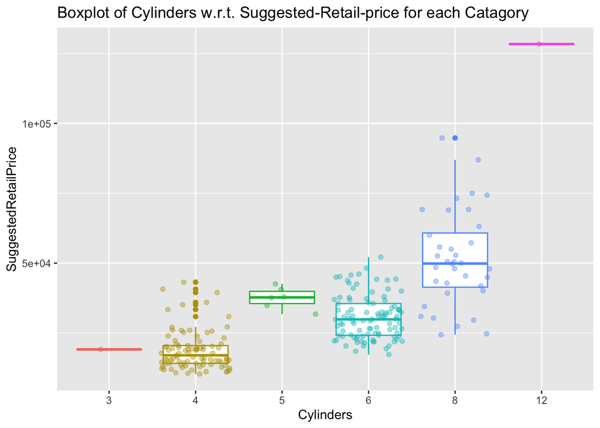

Notice, we only have one observation with 3 Cylinders, and one observation with 12 Cylinders. Moreover the observation with 12 Cylinders is the same observation identified above with a very large Suggested Retail Price.

Now we can round out our exploratory understanding of the data with visualizing the the remaining predictors vs the response w.r.t the Cylinders catagorical variable. For example, lets take a look at “EngineSize”:

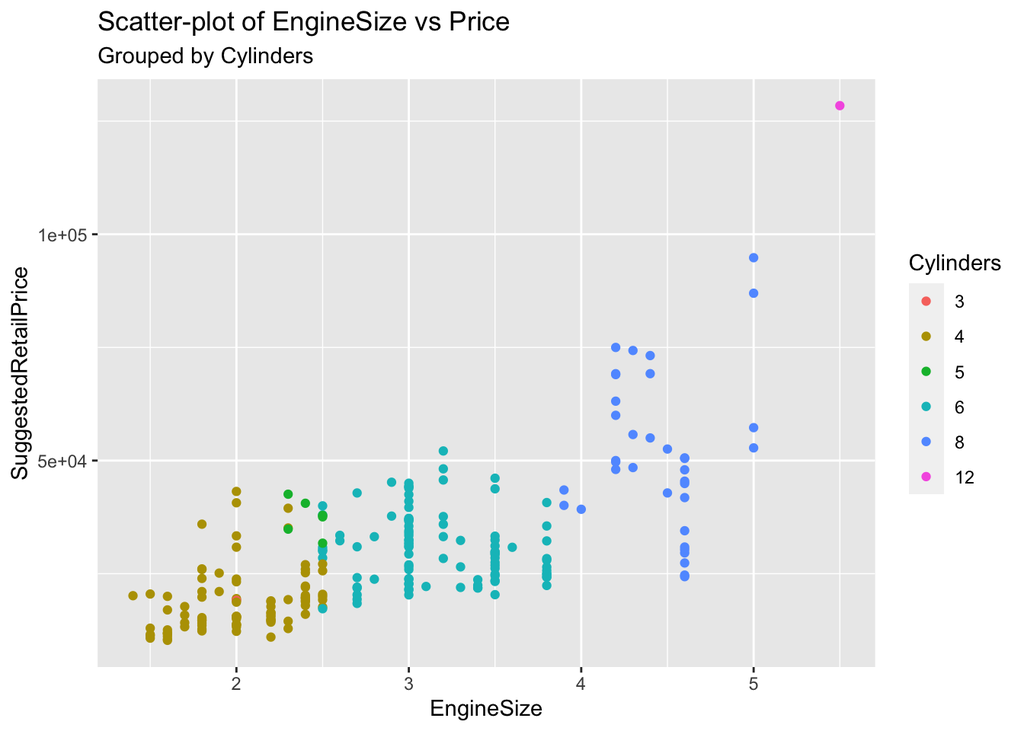

This visualization exercise is repeated for the remaining numerical predictors and can be seen in the appendix in interested.

Note that we don’t need to calculate the correlation between “EngineSize” and “Cylinders” to see that it is quite strong. However, multicollinerarity is a common issue in modeling, thus it is of interest to calculate the amount of correlation among our data to get an idea of how big a problem multicollinerarity will be during modeling.

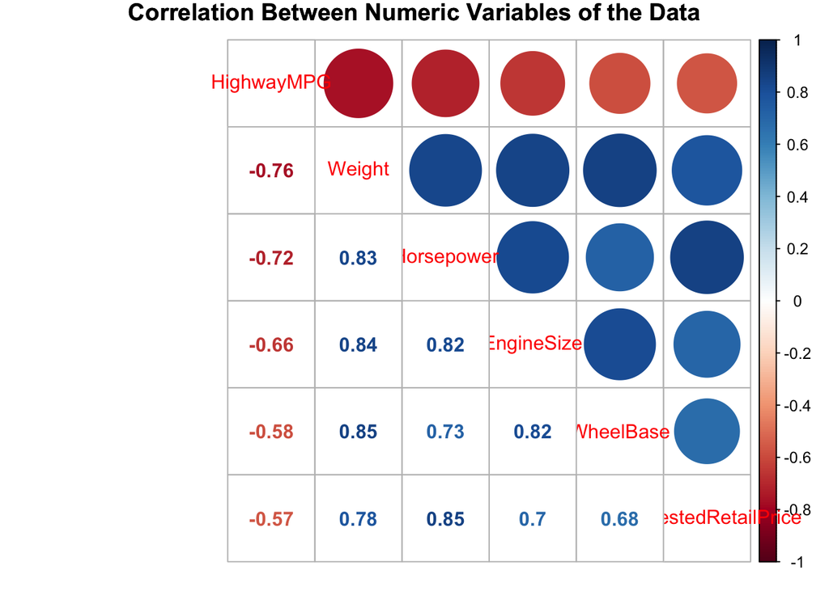

We can see that we indeed have a lot of collinearity among the data, and we will take note of this for modeling purposes.

### Statistical Methods

For modeling our primary goal is:

- Develop a predictive model to predict the average Suggested-Retail-Price for vehicles with specific features

To this end, a Multiple Linear Regression statistical-framework is used. Therefor the first stage of model development we check the assumptions needed to use this modeling framework. An initial look at diagnostic shows that we have some issues with constant-variance among residuals (See Appendix), and we alslo have two point which have a leverage equal to 1. Investigating these points we found they are:

| Vehicle Name | Hybrid | SuggestedRetailPrice | EngineSize | Cylinders | Horsepower | HighwayMPG | Weight | WheelBase |
| --- | --- | --- | --- | --- | --- | --- | --- | --- |
| Mercedes-Benz CL600 2dr | 0 | 128420 | 5.5 | 12 | 493 | 19 | 4473 | 114 |
| Honda Insight 2dr (gas/electric) | 1 | 19110 | 2.0 | 3 | 73 | 66 | 1850 | 95 |

Once again, we see the observation of Mercedes-Benz CL600 2dr appear again. Notice the unique attributes of these observations. The Mercedes is the single observation with 12 cylinders, has the maximum Suggested-Retail-Price, EngineSize, and Horsepower in the data. It also had the worst HighwayMPG’s in the data. The Honda is unique in its attributes as well, most notably it is one of the three Hybrids. However, the Honda is not a unique as the Mercedes, according to Malcolm Reynolds this is an atypical luxury car among vehicles he is interested in. Therefor we will narrow the focus of the analysis and exclude this case.

Finally, a natural log transformation was made on the response variable to satisfy the constant variance of residuals assumption. We can see the resulting diognostic plot here:

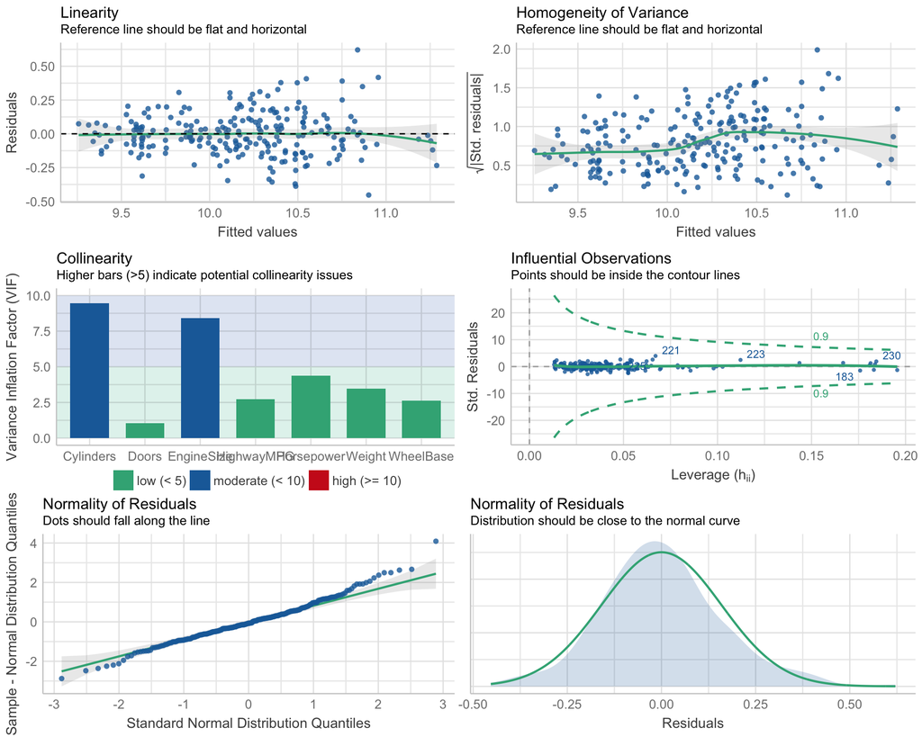

However, we do see that we still have a high amount of collinearity among the predictors that we need to address. Variance-Inflation Factor will be used as a measure or the amount of variance introduced for each predictor, and the predictors with the highest VIF will be systematically removed. (A VIF > 5 is generally considered too high). Here is an initial measure of all the VIF’s:

[output not shown]

Systematically Cylinder was the only selected variable for removal.

##### Model/Varaible Selection for Prediction

Since our goal is to create a strong predictive model we must consider the possibility of overfitting the data. In order to reduce the amount of overfitting done by the model on the training data we will reduce the complexity of the model further by performing feature selection. A cross-validation approach is used to determine the optimal **number** of variables to use.

Cross-Validation Procedure:

- 10-fold CV will be used
- For each fold, the training data is used to perform best sub-set selection by identifying the best model that contains a given number of predictors, where best is quantified using RSS
- Since we have 6 possible variables to begin with, this will produce 6 different models for each fold, one for each size of predictors (1,2,3,4,5, and 6)
- An objective measure of fit (RMSE) is then computed on the test data for each of the 6 models for each fold
- the Averaged CV metric for each model will then be used to pick the best number of predictors

Note, we use cross-validation to select the best number of predictors for the final model. We let the data select which variables will fill this number. Once a number of predictors is selected via CV, this number is used to fit the model on the whole data set in order to make predictions. Cross-Validation results can be seen here:

| cv_single_variable_rmse | cv_two_variable_rmse | cv_three_variable_rmse | cv_four_variable_rmse | cv_five_variable_rmse | cv_full_variable_rmse |
| --- | --- | --- | --- | --- | --- |
| 0.2396235 | 0.1931618 | 0.1853742 | 0.1828635 | 0.1738482 | 0.1755503 |

It seems that using 1-4 variables we might be underfitting, and with 6 we are overfitting, thus we will use a 5 variable model. Note this is inline with using a Best-subset procedure with an objective measure of fit that penalizes predictors (adjusted-R^2) on the entire data set.

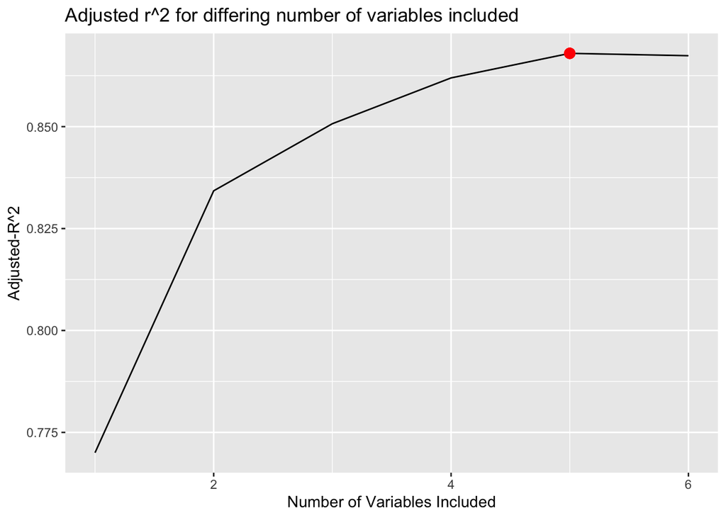

For the model to be used in production (for predicting new vehicles), the variables to be used are determined via RSS as mentioned above, and they are:

| Predictors |
| --- |
| EngineSize |
| Horsepower |
| HighwayMPG |
| Weight |
| Doors |

### Results

Finally, we will now used the model developed above to predict the average suggested retail price for a vehicle that is a 3.5 L engine size, has 6 Cylinders, 210 Horsepower, gets 29 HWY MPG, weighs 4210 lbs and has a wheelbase of 115. The vehicle is not a hybrid. Since the number of doors is not specified we will give results for both cases. Moreover a Boot-strap 95% confidence interval is given for this cars average price.

| new_car | BS_lower_bound | BS_upper_bound |
| --- | --- | --- |
| With 2-Doors | 44830.15 | 53374.86 |
| With 4-Doors | 41391.88 | 48065.35 |

**Note:** Due to the high amount of mulitcollinearity found in exploring the data coefficient analysis is omitted here. If this is of intrest future work may consist of the development of individual models to examin their impact on the vehicles price.

### Appendix

**Code Available Upon Request**

##### Additional Figures

**Additional Exploratory plots:**

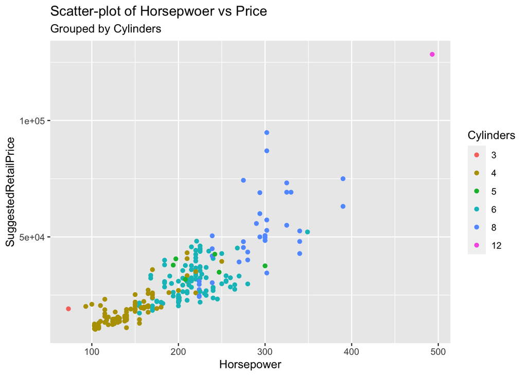

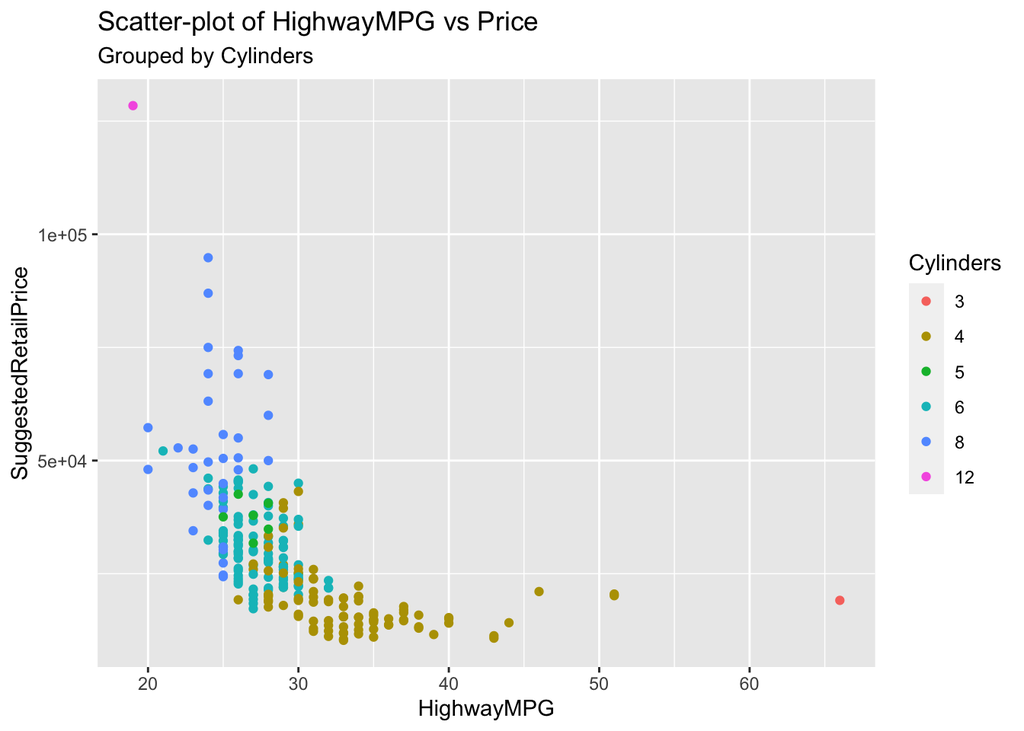

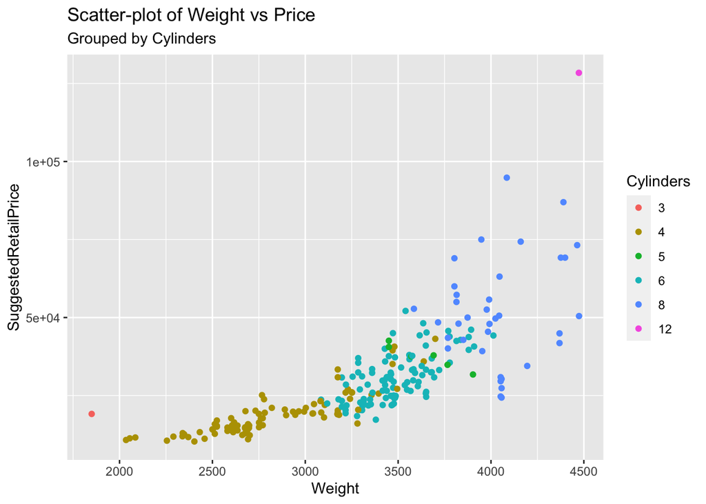

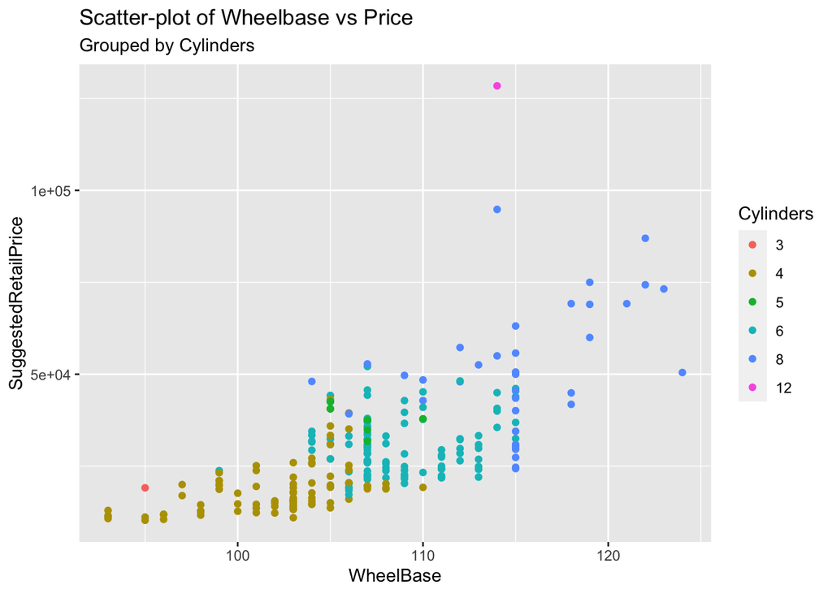

**Initial Diagnostic plots:** Note, two points are not plotted due to leverage equal to 1

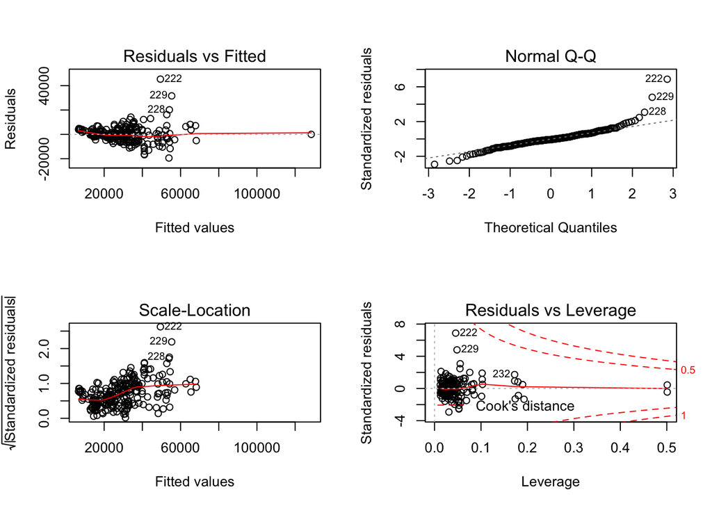